# Activity Monitors

Michael Lamanuzzi

March 21, 2015

## Background (from course website)

Using devices such as Jawbone Up, Nike FuelBand, and Fitbit it is now possible to collect a large amount of data about personal activity relatively inexpensively. These type of devices are part of the quantified self movement – a group of enthusiasts who take measurements about themselves regularly to improve their health, to find patterns in their behavior, or because they are tech geeks. One thing that people regularly do is quantify how much of a particular activity they do, but they rarely quantify how well they do it. In this project, your goal will be to use data from accelerometers on the belt, forearm, arm, and dumbell of 6 participants. They were asked to perform barbell lifts correctly and incorrectly in 5 different ways. More information is available from the website here: http://groupware.les.inf.puc-rio.br/har (see the section on the Weight Lifting Exercise Dataset).

## Cleaning the data

```r
library(ggplot2);library(rattle);library(caret);library(rpart.plot);library(randomForest)
# load the training set (will be split into train and test sets) and final testing set
# Data set contains NA, "", and #DIV/0!, we will mark all of these values NA
trainingSet <- read.csv("pml-training.csv", header=T, na.strings=c("NA","","#DIV/0!"))
testSet <- read.csv("pml-testing.csv", header=T, na.strings=c("NA","","#DIV/0!"))

# Create training and test sets from training data, 70% training, 30% testing
inTrain <- createDataPartition(y=trainingSet$classe,
                               p=0.7,list=FALSE)
myTraining <- trainingSet[inTrain,]
myTesting <- trainingSet[-inTrain,]

dim(myTraining);dim(myTesting)
```

```
## [1] 13737   160
```

```
## [1] 5885  160
```

```r
cleanData <- function(data) {
  # remove non-predictor columns
  drops <- c("cvtd_timestamp", "new_window", "num_window","raw_timestamp_part_1", "raw_timestamp_part_2","user_name","X")
  data <- data[,!(names(data) %in% drops)]
  # remove cols that have NAs
  data <- data[, colSums(is.na(data)) == 0]
  return(data)
}

myTraining <- cleanData(myTraining)
myTraining$classe <- factor(myTraining$classe)
myTesting <- cleanData(myTesting)
```

## Draw a decision tree

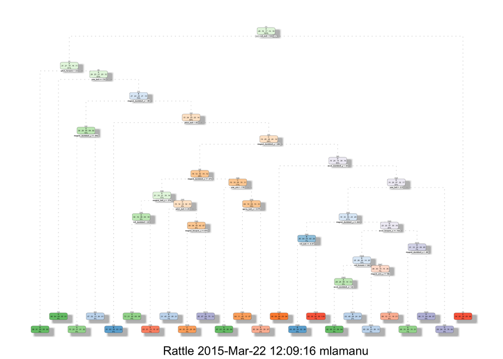

```r
# try a decision tree
modDecTree <- rpart(classe~., data=myTraining, method="class")
fancyRpartPlot(modDecTree)
```

Based on lectures, Random Forests will likely provide one of the best models for this type of data

```r
# create a random forest model from training set
modRandomForest <- train(classe~.,method="rf",data=myTraining,trControl=trainControl(method='cv'),number=5,allowParallel=TRUE)
pred <- predict(modRandomForest, myTesting,type="class")
```

## Calculate confusion matrix and error rate for cross-validation

```r
cm <- confusionMatrix(pred,myTesting$classe)
overall.accuracy <- cm$overall['Accuracy']

# We can see the in-sample accuracy is:
overall.accuracy
```

```
##  Accuracy
## 0.9954121
```

```r
# so the out-of-sample error rate is expected to be:
errorRate <- (1-overall.accuracy)
errorRate
```

```
##    Accuracy
## 0.004587935
```

## Create predictions for final testing set

```r
# predict testing set
finalPredictions <- predict(modRandomForest,testSet,type="class")
finalPredictions
```

```
##  1  2  3  4  5  6  7  8  9 10 11 12 13 14 15 16 17 18 19 20
##  B  A  B  A  A  E  D  B  A  A  B  C  B  A  E  E  A  B  B  B
## Levels: A B C D E
```

The model correctly identified all 20 testing samples, so the effective error rate on that data set is 0.00%.

```r
# Generating files for submission
# function from assignment
pml_write_files = function(x){
  n = length(x)
  for(i in 1:n){
    filename = paste0("problem_id_",i,".txt")
    write.table(x[i],file=filename,quote=FALSE,row.names=FALSE,col.names=FALSE)
  }
}

pml_write_files(finalPredictions)
```